# Exponential Distribution in R

Rehab Fathi

April 6, 2017

## Overview

In this project, I will investigate the exponential distribution in R and compare it with the Central Limit Theorem. I will investigate the distribution of averages of 40 exponentials with a thousand simulations.

## Simulations

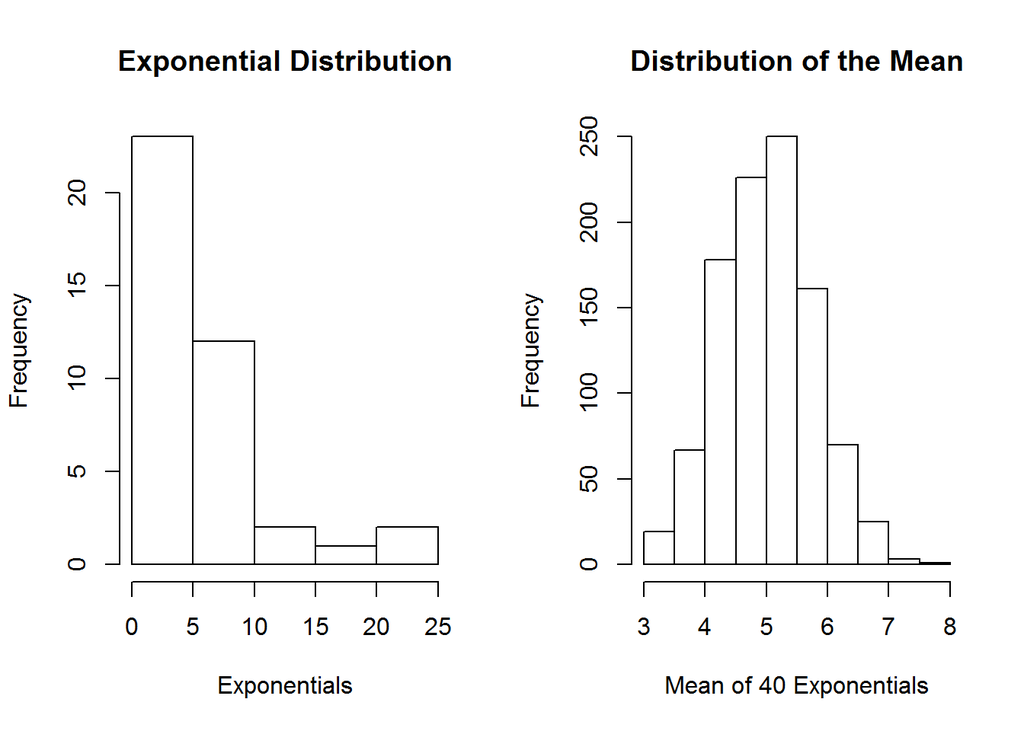

The figures show the exponential distribution compared to the means of 1000 simulations of 40 samples of the exponential distribution. The rate parameter is set to 0.2

## Sample mean versus theoretical mean

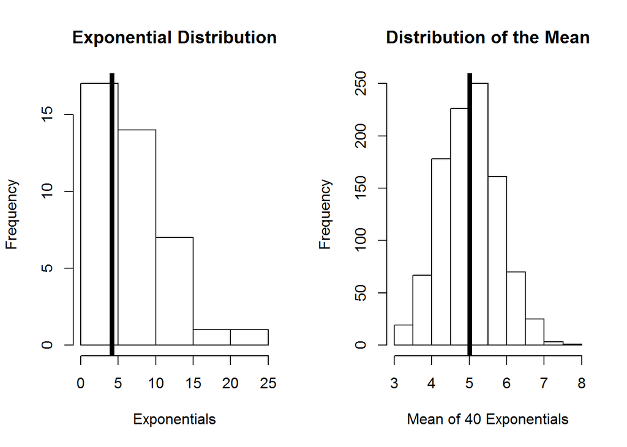

## Sample variance versus theoretical variance

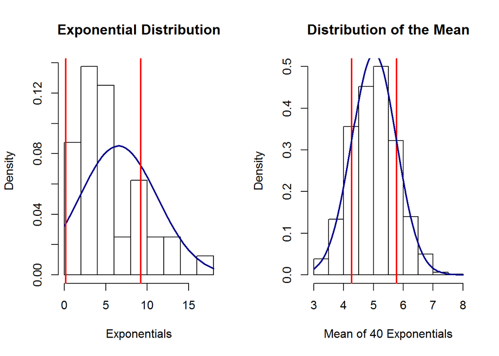

## Sample distribution

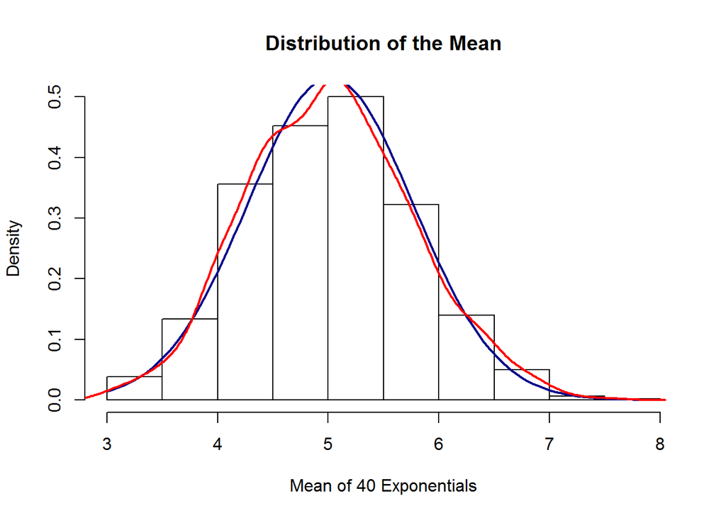

The red curve shows the distribution of the sample of means while the blue curve shows the normal distribution. The distribution of means is a little skewed but it is approximately a normal distribution. Another property of a normal distribution is that the mean is equal to the median, the mean of the distribution is 5 and the median is 4.93.